# Homework2

Jeff Nguyen

06/11/2020

**Pre-MFE Probability Seminar**  
**Baruch College, Fall 2020**

Homework 02  
Student Name: Ngoc Son (Jeff) Nguyen

# **Question 1**

Because X, Y are independent random variables:
$$\begin{equation}
\begin{aligned}
P(Y > 11 \mid X > 12) & = P(Y > 11) = \frac{15}{22} \\
\end{aligned}
\end{equation}$$

Thus, based on the property of distribution function of a random variable:
$$\begin{equation}
\begin{aligned}
P(Y \leqslant 11) & = 1 - P(Y > 11) \\
& = 1 - \frac{15}{22} \\
& = \frac{7}{22} \\
\end{aligned}
\end{equation}$$

Furthermore, based on the definition of the cumulative distribution fucntion of Y, we have:
$$\begin{equation}
\begin{aligned}
P(Y \leqslant 11) & = \sum_{y_0 < y} P(Y = y_0) \\
\text{or in this case:} \\
\frac{7}{22} & = P(Y = 10) + P(Y = 11) \\
& = P(Y = 10) + \frac{2}{11} \\
\Rightarrow P(Y = 10) & = \frac{7}{22} - \frac{2}{11} \\
& = \frac{3}{22}
\end{aligned}
\end{equation}$$

With the given set $\omega = \{10, 11, 12, ..., 110\}$, we have $P(X + Y = 20) = P(\{\omega: X(\omega) + Y(\omega) =20\})$.  
We can see that the only possible scenario for $\{\omega: X(\omega) + Y(\omega) =20\}$ is $\omega: \{X(\omega) = 10, Y(\omega) = 10\}$.  
Thus:

$$\begin{equation}
\begin{aligned}
P(X + Y = 20) & = P(X = 10, Y = 10) \\
& = P(X = 10) * P(Y = 10) \quad \text{(Properties of independence random variables)} \\
& = \frac{3}{11} * \frac{3}{22} \\
& = \frac{9}{242} \\
\text{Therefore, we have the result we are looking for:} \\
242 * P(X + Y = 20) & = 242 * \frac{9}{242} \\
& = 9
\end{aligned}
\end{equation}$$

# **Question 2**

## (a) Sketch the graph of F and show that F is the cdf for a discrete random variable.

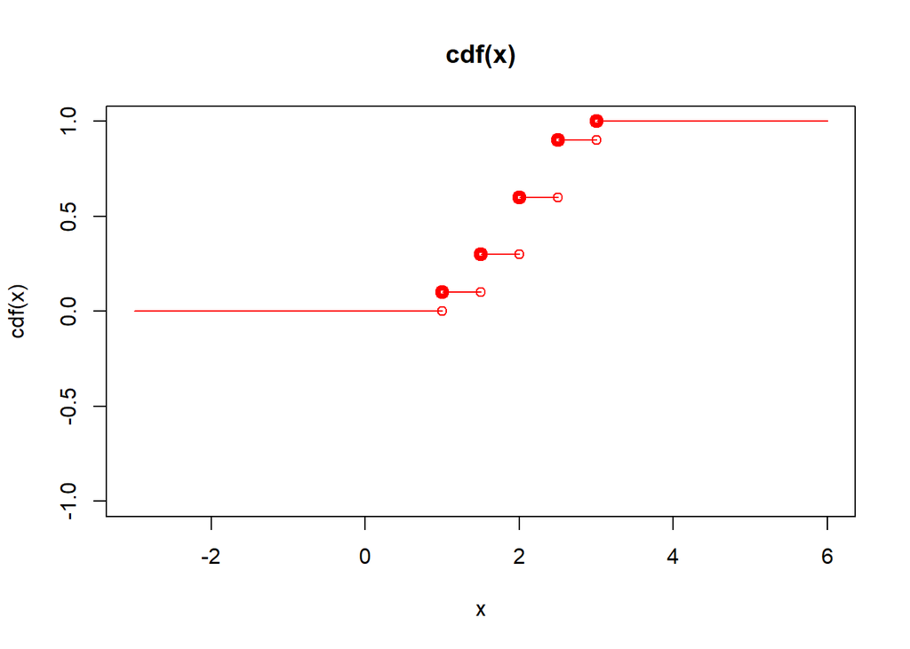

```r
# R plotting of the given cdf function
x <- c(-3, 6)
y <- 0*x
plot(x, y, xlab="x", ylab="cdf(x)", type="n", main="cdf(x)")
par(new=TRUE)

points(1, 0, pch=21, col="red")
segments(x0=-3, y0=0, x1=1, y1=0, col="red")

points(1, 1/10, pch=21, lwd=4, col="red")
segments(x0=1, y0=1/10, x1=3/2, y1=1/10, col="red")
points(3/2, 1/10, pch=21, col="red")

points(3/2, 3/10, pch=21, lwd=4, col="red")
segments(x0=3/2, y0=3/10, x1=2, y1=3/10, col="red")
points(2, 3/10, pch=21, col="red")

points(2, 6/10, pch=21, lwd=4, col="red")
segments(x0=2, y0=6/10, x1=5/2, y1=6/10, col="red")
points(5/2, 6/10, pch=21, col="red")

points(5/2, 9/10, pch=21, lwd=4, col="red")
segments(x0=5/2, y0=9/10, x1=3, y1=9/10, col="red")
points(3, 9/10, pch=21, col="red")

points(3, 1, pch=21, lwd=4, col="red")
segments(x0=3, y0=1, x1=6, y1=1, col="red")
```

We can see that $F_X(x)$ is a cumulative distribution function of a discrete random variable $X$ as $F_X(x)$ is defined for every $x$ and its graph is mostly flat, except jumps. It jumps at the points in the support of $X$. We can clearly see $F_X(x)$ is a step-function with left-closed and right-open intervals, denoted by the filled red circles and un-filled red circles on the graph, respectively.

## (b) Find the corresponding pmf f and sketch the graph.

| x | $F_X(x)$ | $p_X(x)$ |
| --- | --- | --- |
| $0$ | $0$ |  |
| $1$ | $\frac{1}{10}$ | $F_X(1) - F_X(1-) = \frac{1}{10} - 0 = \frac{1}{10}$ |
| $\frac{3}{2}$ | $\frac{3}{10}$ | $F_X(\frac{3}{2}) - F_X(\frac{3}{2}-) = \frac{3}{10} - \frac{1}{10} = \frac{1}{5}$ |
| $2$ | $\frac{6}{10}$ | $F_X(2) - F_X(2-) = \frac{6}{10} - \frac{3}{10} = \frac{3}{10}$ |
| $\frac{5}{2}$ | $\frac{9}{10}$ | $F_X(\frac{5}{2}) - F_X(\frac{5}{2}-) = \frac{9}{10} - \frac{6}{10} = \frac{3}{10}$ |
| $3$ | $1$ | $F_X(3) - F_X(3-) = 1 - \frac{9}{10} = \frac{1}{10}$ |

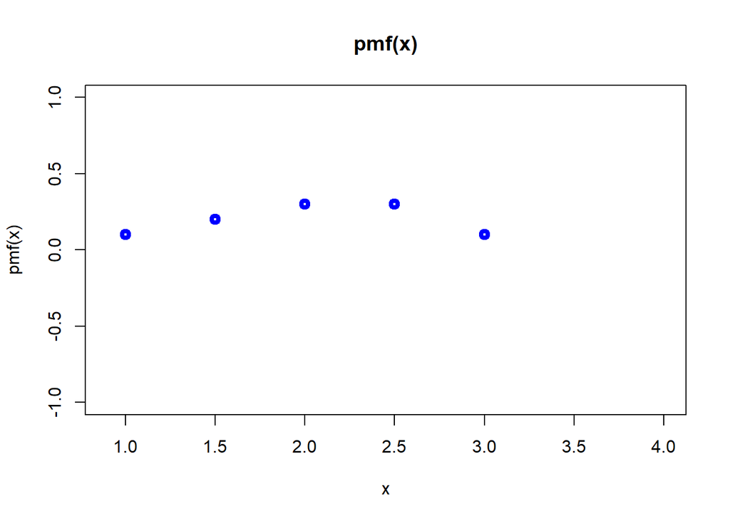

```r
# R plotting of the pmf function
x <- c(9/10, 4)
y <- 0*x
plot(x, y, xlab="x", ylab="pmf(x)", type="n", main="pmf(x)")
par(new=TRUE)

points(1, 1/10, pch=21, lwd=4, col="blue")

points(3/2, 2/10, pch=21, lwd=4, col="blue")

points(2, 3/10, pch=21, lwd=4, col="blue")

points(5/2, 3/10, pch=21, lwd=4, col="blue")

points(3, 1/10, pch=21, lwd=4, col="blue")
```

## (c) Find the probability $P(2 \leqslant X < 3)$

According to the property of the distribution function $F_X(x)$ of a random variable $X$ with $a<b$ and $a,b \in \Re$:
$$\begin{equation}
\begin{aligned}
P(a \leqslant X < b) & = F(b-) - F(a-) \\
\text{we can easily prove this: } \\
\{a \leqslant X < b \} & = \{X < b\} \backslash \{X < a\} \\
\text{thus, based on properties of probabilityt measure:} \\
P(a \leqslant X < b) & = P(X<b) - P(X<a) \\
& = F(b-) - F(a-) \\
\text{substituting a=2 and b=3:} \\
P(2 \leqslant X < 3) & = F(3-) - F(2-) \\
& = \frac{9}{10} - \frac{3}{10} \\
& = \frac{6}{10} \\
& = \frac{3}{5} \\
\end{aligned}
\end{equation}$$

# **Question 3**

## (a)

By definition of a cdf of $Y$, denoted by $F_Y(y)$, we have:
$$\begin{equation}
\begin{aligned}
F_Y(y) & = P(Y \leqslant y) \\
& = P(aX + b \leqslant y) \\
& = P(aX \leqslant (y - b)) \\
& = P\Big(X \leqslant \frac{y-b}{b}\Big) \\
& = F_X\Big(\frac{y-b}{a}\Big)
\end{aligned}
\end{equation}$$

## (b)

By definition of the cdf of $X$, denoted by $F_X(x)$, we have:
$$\begin{equation}
\begin{aligned}
F_X(x) & = P(X \leqslant x) \\
\end{aligned}
\end{equation}$$

Since $Q_X(p)$ is the inverse of $F_X(x)$, by definition, we have:
$$\begin{equation}
\begin{aligned}
F_X(Q_X(p)) & = P(X \leqslant Q_X(p)) \\
p & = P\Big( \frac{Y - b}{a} \leqslant Q_X(p)\Big) \quad \text{linear transformation of X to Y} \\
p & = P(Y \leqslant aQ_X(p) + b) \\
\text{thus, by definition of the quantile function: } \\
Q_Y(p) & = aQ_X(x) + b \\
\end{aligned}
\end{equation}$$

# **Question 4**

Let $X$ be the number of heads in n coin tosses. $X$ follows a binomial distribution with $p=\frac{1}{2}$. We have X as a continuous random variable with finite expectation.  
We have $X = I_1 + I_2 + ... + I_n$ with $I_i$ be the number of heads on the $i^{th}$ toss.  
Thus: $E(X) = \sum_{i=1}^n I_{E_i} = np$  
In addition: $Var(X) = \sum_{i=1}^n Var(I_{E_i}) = \sum_{i=1}^n p(1-p) = np(1-p)$

With $X$ as the number of heads in n coin tosses, we have $n-X$ as the number of tails in those n coin tosses. The expected product of the number of heads and the number of tails is then:

$$\begin{equation}
\begin{aligned}
E(X(n-X)) & = E(nX - X^2)
\end{aligned}
\end{equation}$$

Because X as a continuous random variable with finite expectation:

$$\begin{equation}
\begin{aligned}
E(X(n-X)) & = E(nX) - E(X^2) \\
& = nE(X) - E(X^2) \quad \text{(property of expectation)} \\
& = nE(X) - [(E(X)^2) + Var(X)] \\
& = nnp - (np)^2 - np(1-p) \\
& = n^2p - n^2p^2 - np(1-p) \\
& = \frac{n^2}{2} - \frac{n^2}{4} - \frac{n}{4} \quad \Big(\text{substituting} \quad p = \frac{1}{2} \Big) \\
& = \frac{n^2}{4} - \frac{n}{4}
\end{aligned}
\end{equation}$$

# **Question 5**

We have the same space $\Omega = \{BBBBBBBBGGGGGGG, BBBBBBBGBGGGGGG, ... \}$  
We are looking for expected number of ordered pair $s = \{BG\}$ or $s = \{GB\}$

Let $B$ and $G$ denoting the type, corresponding to “Boy” and “Girl” respectively.  
Consider the first pair of kids. We have the probability that this ordered pair of two kids has different gender is:

$$\begin{equation}
\begin{aligned}
P & = P({BG}) + P({GB}) \\
& = 2*P({BG}) \\
\end{aligned}
\end{equation}$$

The above holds true because the process of establishing the ordered pair is indifferent to the outcome, i.e. the ordered inside the pair.

To find $P({BG})$, we note that for a pair of two kids, there are $15$ ways to arrange seating for 1 kid. Consequently, there are $14$ ways to arrange seating for the immediate following kid. Thus, there are $15*14 = 210$ ways to arrange seating for this pair of kid.

Further note that there $8*7 = 56$ ways to arrange seating for a pair of $B$ and $G$.

Therefore, we have $P(\{BG\}) = \frac{56}{210} = \frac{4}{15}$. Consequently, $P = 2*\frac{4}{15} = \frac{8}{15}$. In other world, the probability that an pair of kids will have different “types” is $\frac{8}{15}$.

Let $X$ be the binomial random variable whose value of $1$ representing the kids in the event the kids at position $X_k$ and $X_{k+1}$ having different “type”: “B” or “G”. Based on the addition properties of expectation, we have: $E^* = \sum\limits_{i=1}^{n=14} E(X) = 14 * E(X)$.